# Μέσος όρος και απόκλιση με ολοκληρώματα

Από τις απλές συναρτήσεις στις πυκνότητες πιθανότητας

Συγγραφέας

[Kostas Maistrelis](https://maistrelis.com)

Δημοσιευμένο

28 Σεπτεμβρίου 2026

Το κείμενο εξηγεί πώς υπολογίζουμε με ολοκληρώματα δύο βασικά περιγραφικά μέτρα: τον **μέσο όρο** και τη **μέση απόλυτη απόκλιση**. Στο τέλος προσθέτει και τη **διακύμανση**. Ξεκινάμε από απλές συναρτήσεις, όπου το ύψος της καμπύλης είναι η τιμή. Μετά περνάμε στις πυκνότητες πιθανότητας, όπου το ύψος της καμπύλης είναι βάρος.

**Τι χρειάζεται να ξέρεις:** τι είναι ο μέσος όρος μιας λίστας αριθμών, και τι είναι ορισμένο ολοκλήρωμα (το εμβαδόν κάτω από μια καμπύλη), μαζί με τον υπολογισμό του για απλά πολυώνυμα, π.χ. $\int_0^1 x^2\,dx = 1/3$. Δεν χρειάζονται πιθανότητες ούτε R. Ο κώδικας είναι κρυμμένος και ανοίγει με το «Κώδικας», μόνο αν θέλεις να δεις πώς βγήκε ένας αριθμός.

Συνοδευτικά κείμενα:

- Ο διάμεσος: έχει δικές του ιδιαιτερότητες, γι’ αυτό είναι χωριστά.
- Η κανονική κατανομή σε διάστημα: τι αλλάζει όταν κρατάμε μόνο ένα κομμάτι της καμπύλης.

# Μέρος Α: απλές συναρτήσεις

## Μέσος όρος των τιμών μιας συνάρτησης

Όταν έχουμε $n$ αριθμούς $y_1, \dots, y_n$, ο μέσος όρος είναι

$$\bar{y} = \frac{1}{n} \sum_{i=1}^{n} y_i$$

Προσθέτουμε όλες τις τιμές και διαιρούμε με το πλήθος τους.

Τώρα ας πάρουμε μια συνάρτηση $h(x)$ σε ένα διάστημα $[a, b]$. Κάθε $x$ του διαστήματος δίνει μια τιμή $y = h(x)$, και το ύψος της καμπύλης **είναι η τιμή**, όπως σε κάθε γραφική παράσταση. Δεν έχουμε όμως πλέον $n$ μεμονωμένες τιμές. Έχουμε άπειρες, μία για κάθε $x$. Πώς παίρνουμε τον μέσο όρο άπειρων τιμών;

### Από το άθροισμα στο ολοκλήρωμα

Ξεκινάμε από αυτό που ξέρουμε. Χωρίζουμε το $[a, b]$ σε $n$ ίσα κομμάτια, παίρνουμε από ένα $x_i$ στο μέσο καθενός, και υπολογίζουμε τον συνηθισμένο μέσο όρο των $n$ τιμών $h(x_i)$.

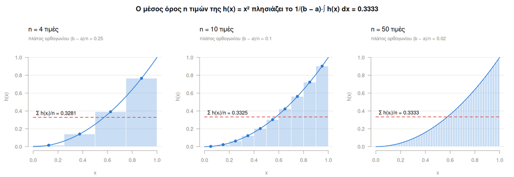

Εικόνα 1: Ο μέσος όρος $n$ ισαπεχουσών τιμών της $h(x) = x^2$ (κόκκινη γραμμή). Κάθε τιμή είναι το ύψος ενός ορθογωνίου. Όσο μεγαλώνει το $n$, ο μέσος όρος σταθεροποιείται στο $1/3$. (`function_values.R`)

Στην Εικόνα 1 κάθε τιμή $h(x_i)$ είναι το ύψος ενός ορθογωνίου με πλάτος $\Delta x = \frac{b-a}{n}$. Επειδή $\frac{1}{n} = \frac{\Delta x}{b - a}$, ο μέσος όρος γράφεται:

$$\bar{y}_n = \frac{1}{n} \sum_{i=1}^{n} h(x_i)
= \frac{1}{b - a} \underbrace{\sum_{i=1}^{n} h(x_i)\,\Delta x}_{\text{εμβαδόν ορθογωνίων}}$$

Το άθροισμα είναι το συνολικό εμβαδόν των ορθογωνίων. Όσο μεγαλώνει το $n$, τα ορθογώνια στενεύουν και γεμίζουν ακριβώς την περιοχή κάτω από την καμπύλη. Το άθροισμα γίνεται **ολοκλήρωμα**, και αυτός είναι ακριβώς ο ορισμός του ολοκληρώματος. Με $n = 4$ τιμές ο μέσος είναι 0.3281, με 10 είναι 0.3325, με 50 είναι ήδη 0.3333:

$$\bar{y} = \frac{1}{b - a} \int_a^b h(x)\,dx$$

| Διακριτές τιμές | Τιμές συνάρτησης |
| --- | --- |
| τιμή $y_i$ | τιμή $h(x)$ |
| άθροισμα $\sum$ | ολοκλήρωμα $\int_a^b \dots dx$ |
| διαίρεση με το πλήθος $n$ | διαίρεση με το μήκος $b - a$ |

**Κώδικας**

```r
riemann_mean <- function(h, n) {
  xi <- (seq_len(n) - 0.5) / n     # τα μέσα των n κομματιών του [0, 1]
  mean(h(xi))
}
sapply(c(4, 10, 50, 1000), function(n) riemann_mean(function(x) x^2, n))
```

```
[1] 0.3281250 0.3325000 0.3333000 0.3333333
```

### Τρεις συναρτήσεις

Χρησιμοποιούμε τρεις αύξουσες συναρτήσεις στο $[0, 1]$: μια ευθεία, μια που λυγίζει προς τα πάνω (**κυρτή**) και μια που λυγίζει προς τα κάτω (**κοίλη**).

**Κώδικας**

```r
a <- 0
b <- 1
h_lin <- function(x) 2 * x
h_cvx <- function(x) x^2
h_ccv <- function(x) 2 * x - x^2

mean_values <- function(h) integrate(h, a, b)$value / (b - a)

c(`2x` = mean_values(h_lin), `x²` = mean_values(h_cvx), `2x − x²` = mean_values(h_ccv))
```

```
       2x        x²   2x − x²
1.0000000 0.3333333 0.6666667
```

Εδώ τα ολοκληρώματα βγαίνουν και με το χέρι:

$$\int_0^1 2x\,dx = 1, \qquad \int_0^1 x^2\,dx = \frac{1}{3}, \qquad
\int_0^1 (2x - x^2)\,dx = 1 - \frac{1}{3} = \frac{2}{3}$$

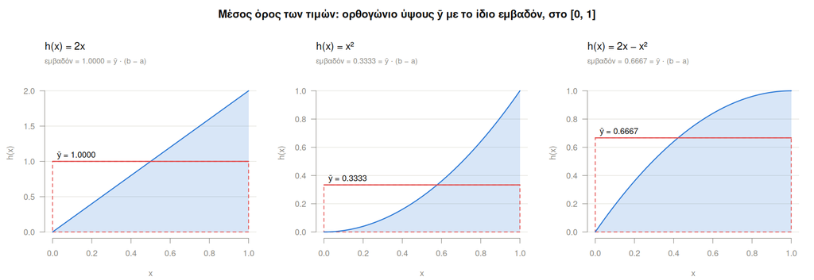

Εικόνα 2: Ο μέσος όρος των τιμών ως ορθογώνιο. Το ορθογώνιο με ύψος $\bar{y}$ (κόκκινο) έχει ακριβώς το ίδιο εμβαδόν με την περιοχή κάτω από την καμπύλη (μπλε). (`function_values.R`)

Η Εικόνα 2 δείχνει τι σημαίνει ο τύπος γεωμετρικά. Αν πολλαπλασιάσουμε και τις δύο πλευρές με $b - a$:

$$\bar{y} \cdot (b - a) = \int_a^b h(x)\,dx$$

Αριστερά είναι το εμβαδόν ενός ορθογωνίου με ύψος $\bar{y}$ και πλάτος $b - a$. Δεξιά είναι το εμβαδόν κάτω από την καμπύλη. Ο μέσος όρος είναι λοιπόν το ύψος στο οποίο πρέπει να «ισιώσει» η καμπύλη ώστε να κρατήσει το ίδιο εμβαδόν. Όσο περισσεύει πάνω από την κόκκινη γραμμή, τόσο λείπει κάτω από αυτήν.

## Μέση απόλυτη απόκλιση των τιμών

Ο μέσος όρος λέει πού είναι το κέντρο των τιμών. Η **μέση απόλυτη απόκλιση** λέει πόσο **απλωμένες** είναι γύρω από το κέντρο: πόσο απέχει, κατά μέσο όρο, μια τιμή από το $\bar{y}$.

Η λογική είναι ακριβώς η ίδια με εκείνη του μέσου όρου. Στη θέση της ποσότητας $h(x)$ βάζουμε την απόσταση $|h(x) - \bar{y}|$ και παίρνουμε τον μέσο όρο της:

$$\text{ΜΑΑ} = \frac{1}{b - a} \int_a^b |h(x) - \bar{y}|\,dx$$

Η **απόλυτη τιμή** είναι απαραίτητη. Χωρίς αυτήν, οι τιμές κάτω από το $\bar{y}$ δίνουν αρνητικές διαφορές, οι οποίες αναιρούν ακριβώς τις θετικές, και το ολοκλήρωμα είναι **πάντα 0**:

**Κώδικας**

```r
ybar <- mean_values(h_lin)
integrate(function(x) h_lin(x) - ybar, a, b)$value        # χωρίς απόλυτη τιμή
```

```
[1] 3.516356e-18
```

**Κώδικας**

```r
integrate(function(x) abs(h_lin(x) - ybar), a, b)$value   # με απόλυτη τιμή
```

```
[1] 0.5
```

Αυτό δεν είναι σύμπτωση. Είναι ακριβώς αυτό που είδαμε στην Εικόνα 2: ό,τι περισσεύει πάνω από το $\bar{y}$ ισούται με ό,τι λείπει κάτω από αυτό.

### Η διαδικασία σε τέσσερα βήματα

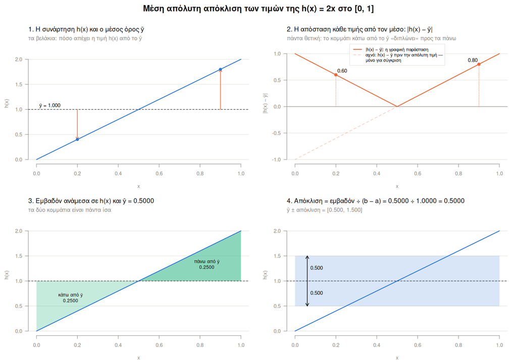

Εικόνα 3: Μέση απόλυτη απόκλιση των τιμών της $h(x) = 2x$ βήμα-βήμα. (`function_values.R`)

Η Εικόνα 3 δείχνει τον υπολογισμό για την $h(x) = 2x$, ένα βήμα σε κάθε πάνελ:

**Βήμα 1: η συνάρτηση και ο μέσος όρος** (πάνω αριστερά). Η οριζόντια διακεκομμένη γραμμή είναι το $\bar{y} = 1$. Τα πορτοκαλί βελάκια δείχνουν πόσο απέχουν από αυτό δύο τιμές: η μία είναι κάτω από το $\bar{y}$, η άλλη πάνω.

**Βήμα 2: η απόσταση $|h(x) - \bar{y}|$** (πάνω δεξιά). Η αχνή διακεκομμένη γραμμή είναι η $h(x) - \bar{y}$ πριν από την απόλυτη τιμή, και είναι αρνητική αριστερά. Η απόλυτη τιμή «διπλώνει» το αρνητικό κομμάτι προς τα πάνω, και έτσι σχηματίζεται το «V». Οι δύο τελείες είναι τα ίδια σημεία με τα βελάκια του βήματος 1.

**Βήμα 3: το εμβαδόν ανάμεσα στην καμπύλη και στο $\bar{y}$** (κάτω αριστερά). Είναι το ίδιο εμβαδόν με εκείνο κάτω από το «V» του βήματος 2, απλώς ζωγραφισμένο πάνω στην αρχική καμπύλη. Το κομμάτι κάτω από το $\bar{y}$ και το κομμάτι πάνω από το $\bar{y}$ είναι **πάντα ίσα**. Είναι η ιδιότητα του μέσου όρου που είδαμε μόλις.

**Βήμα 4: το αποτέλεσμα** (κάτω δεξιά). Διαιρούμε το εμβαδόν με το μήκος $b - a$, όπως στον μέσο όρο. Η τιμή που βγαίνει είναι απόσταση στον άξονα $y$. Η σκιασμένη ζώνη $\bar{y} \pm \text{ΜΑΑ}$ δείχνει πόσο απλώνονται «τυπικά» οι τιμές.

Για την ευθεία βγαίνει και με το χέρι. Τα δύο κομμάτια είναι τρίγωνα με βάση 0.5 και ύψος 1:

$$\int_0^1 |2x - 1|\,dx = 2 \cdot \frac{0.5 \cdot 1}{2} = 0.5$$

### Κυρτή και κοίλη

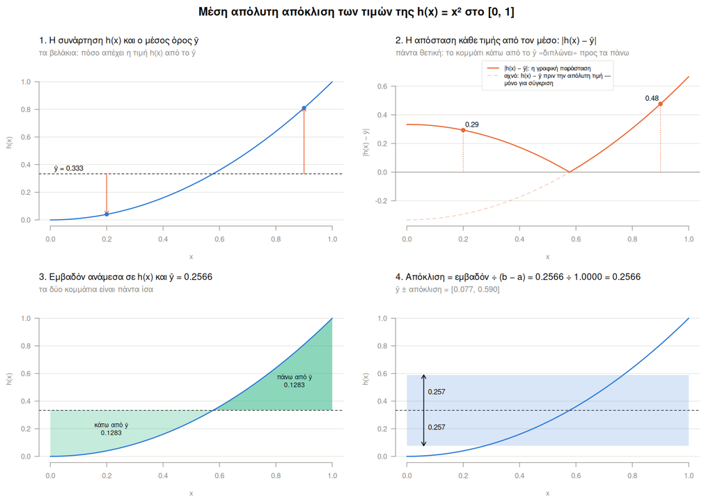

Εικόνα 4: Μέση απόλυτη απόκλιση των τιμών της $h(x) = x^2$. (`function_values.R`)

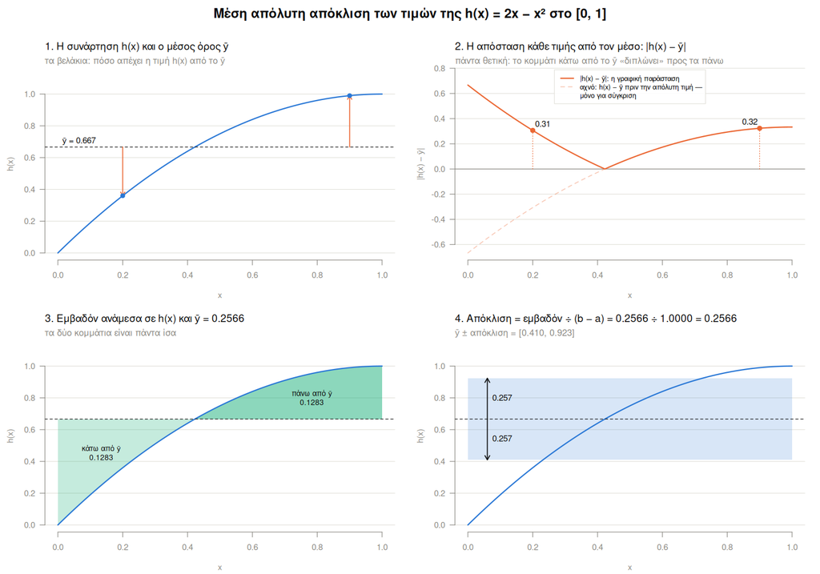

Εικόνα 5: Μέση απόλυτη απόκλιση των τιμών της $h(x) = 2x - x^2$. (`function_values.R`)

**Κώδικας**

```r
# rel.tol: μεγαλύτερη ακρίβεια, γιατί η |·| έχει «γωνία» στο σημείο όπου h(x) = ȳ
mad_values <- function(h) {
  ybar <- mean_values(h)
  integrate(function(x) abs(h(x) - ybar), a, b, rel.tol = 1e-10)$value / (b - a)
}
c(`2x` = mad_values(h_lin), `x²` = mad_values(h_cvx), `2x − x²` = mad_values(h_ccv),
  `4/(9√3)` = 4 / (9 * sqrt(3)))
```

```
       2x        x²   2x − x²   4/(9√3)
0.5000000 0.2566001 0.2566001 0.2566001
```

Σύγκρινε το **βήμα 3** της Εικόνα 4 με εκείνο της Εικόνα 5. Τα πράσινα κομμάτια έχουν **ανάποδο σχήμα**, αλλά ακριβώς **το ίδιο εμβαδόν** (0.1283 το καθένα). Γι’ αυτό οι δύο συναρτήσεις έχουν την ίδια απόκλιση, $4/(9\sqrt{3}) \approx 0.257$.

Ο λόγος είναι ότι $2x - x^2 = 1 - (1 - x)^2$. Η κοίλη είναι η κυρτή αναποδογυρισμένη και καθρεφτισμένη. Παίρνει τις ίδιες τιμές με ανάποδη σειρά, οπότε απλώνεται ακριβώς το ίδιο γύρω από τον μέσο της. Η απόκλιση μετράει **πόσο απλωμένες** είναι οι τιμές, όχι **πού** βρίσκονται.

# Η μετάβαση: από την τιμή στο βάρος

## Το $\frac{1}{b-a}$ ήταν ήδη βάρος

Ξαναγράφουμε τον μέσο όρο των τιμών λίγο διαφορετικά, βάζοντας το $\frac{1}{b-a}$ **μέσα** στο ολοκλήρωμα:

$$\bar{y} = \int_a^b h(x) \cdot \underbrace{\frac{1}{b - a}}_{\text{βάρος}}\,dx$$

Τώρα διαβάζεται έτσι: κάθε τιμή $h(x)$ πολλαπλασιάζεται με ένα **βάρος** $\frac{1}{b-a}$, και το βάρος είναι **ίδιο για όλα τα $x$**. Είναι ακριβώς το $\frac{1}{n}$ του διακριτού μέσου όρου. Το συνολικό βάρος είναι 1: $\int_a^b \frac{1}{b-a}\,dx = 1$.

Μια σταθερή συνάρτηση βάρους με συνολικό βάρος 1 είναι ήδη μια πυκνότητα πιθανότητας. Έχει και όνομα: **ομοιόμορφη κατανομή** στο $[a, b]$. Ό,τι κάναμε στο Μέρος Α ήταν λοιπόν ήδη στατιστική με πυκνότητα. Απλώς η πυκνότητα ήταν επίπεδη και «κρυβόταν» μέσα στο $\frac{1}{b-a}$. Αν ο $X$ διαλέγεται τυχαία και ομοιόμορφα από το $[a, b]$, τότε το $\bar{y}$ είναι ο μέσος όρος της τυχαίας τιμής $h(X)$.

Τι γίνεται αν τα βάρη **δεν** είναι ίσα; Αν κάποιες τιμές εμφανίζονται συχνότερα από άλλες; Τότε το βάρος γίνεται μια συνάρτηση $f(x)$ που δεν είναι επίπεδη: μια γενική **πυκνότητα πιθανότητας**.

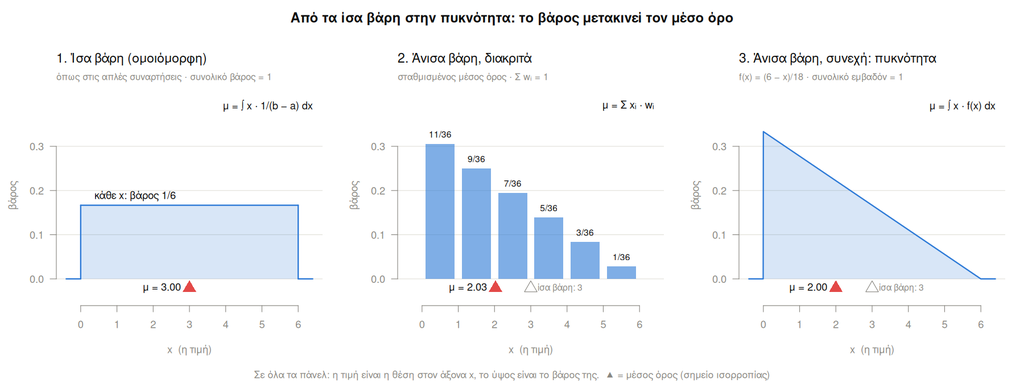

Εικόνα 6: Από τα ίσα βάρη στην πυκνότητα. Σε όλα τα πάνελ η τιμή είναι η θέση στον άξονα $x$ και το ύψος είναι το βάρος της. Το ▲ είναι ο μέσος όρος, το σημείο όπου «ισορροπούν» τα βάρη. Το αχνό △ δείχνει πού ήταν με ίσα βάρη. (`bridge_visual.R`)

Η Εικόνα 6 δείχνει τη μετάβαση σε τρία βήματα, όλα στο $[0, 6]$:

1. **Ίσα βάρη** (αριστερά). Κάθε $x$ έχει το ίδιο βάρος $1/6$. Είναι η ομοιόμορφη κατανομή, δηλαδή η περίπτωση των απλών συναρτήσεων, σχεδιασμένη αυτή τη φορά ως **βάρος**. Ο μέσος όρος είναι στο κέντρο, στο 3.
2. **Άνισα βάρη, διακριτά** (μέση). Έξι τιμές, $0.5, 1.5, \dots, 5.5$, με βάρη $w_i$ που μικραίνουν προς τα δεξιά. Πρόκειται για τον γνωστό **σταθμισμένο μέσο όρο**, όπως σε έναν πίνακα συχνοτήτων ή σε βαθμούς με συντελεστές: $\mu = \sum x_i \cdot w_i$. Επειδή το μεγαλύτερο μέρος του βάρους είναι αριστερά, το σημείο ισορροπίας **μετακινείται** αριστερά, στο 2.03.
3. **Άνισα βάρη, συνεχή** (δεξιά). Οι μπάρες γίνονται μια συνεχής γραμμή, η πυκνότητα $f(x) = (6 - x)/18$. Το άθροισμα γίνεται ολοκλήρωμα: $\mu = \int x \cdot f(x)\,dx = 2$.

Οι μπάρες του μεσαίου πάνελ έχουν πλάτος 1 και ύψος ίσο με την $f$ στο μέσο τους. Είναι δηλαδή τα ορθογώνια της Εικόνα 1 για αυτή την πυκνότητα. Γι’ αυτό ο μέσος τους (2.03) είναι ήδη πολύ κοντά στο ακριβές 2, και θα πλησίαζε κι άλλο με στενότερες μπάρες.

Ο τρόπος υπολογισμού μένει ο ίδιος σε όλα τα πάνελ: τιμή επί βάρος, και άθροισμα ή ολοκλήρωμα. Αυτό που αλλάζει είναι **το σχήμα του βάρους**, και αυτό μετακινεί τον μέσο όρο.

**Κώδικας**

```r
xi <- seq(0.5, 5.5, by = 1)
wi <- (12 - 2 * xi) / 36                       # 11/36, 9/36, ..., 1/36
f_dec <- function(x) (6 - x) / 18
c(`ίσα βάρη` = integrate(function(x) x / 6, 0, 6)$value,
  `Σ xᵢ·wᵢ` = sum(xi * wi),
  `∫ x·f(x) dx` = integrate(function(x) x * f_dec(x), 0, 6)$value)
```

```
   ίσα βάρη     Σ xᵢ·wᵢ ∫ x·f(x) dx
   3.000000    2.027778    2.000000
```

## Προσοχή: αλλάζει ο ρόλος του άξονα $y$

Αυτό είναι το σημείο όπου μπερδεύεται κανείς πιο εύκολα:

|  | Απλή συνάρτηση $h(x)$ | Πυκνότητα $f(x)$ |
| --- | --- | --- |
| η **τιμή** είναι | το ύψος $h(x)$, στον άξονα $y$ | η θέση $x$, στον άξονα $x$ |
| το **βάρος** είναι | σταθερό, $\frac{1}{b-a}$ (δεν σχεδιάζεται) | το ύψος $f(x)$, στον άξονα $y$ |
| μέσος όρος | $\int h(x) \cdot \frac{1}{b-a}\,dx$ | $\int x \cdot f(x)\,dx$ |

Στην πυκνότητα **το ύψος της καμπύλης δεν είναι τιμή**. Γι’ αυτό, όταν θέλουμε την απόσταση από τον μέσο όρο, αφαιρούμε το $\mu$ από το **$x$**, όχι από το $f(x)$. Το $f(x) - \mu$ απλώς θα κατέβαζε την καμπύλη προς τα κάτω και δεν θα μετρούσε καμία απόσταση.

Μια ακόμη διευκρίνιση: το $f(x)$ **δεν είναι η πιθανότητα** να πάρει το $X$ την τιμή $x$. Σε μια συνεχή κατανομή, η πιθανότητα μιας ακριβούς τιμής είναι 0. Η πιθανότητα αφορά ένα διάστημα και είναι το εμβαδόν κάτω από την καμπύλη:

$$P(u \le X \le v) = \int_u^v f(x)\,dx$$

Γι’ αυτό το ύψος $f(x)$ μπορεί ακόμη και να είναι μεγαλύτερο από 1, χωρίς πρόβλημα. Σημασία έχει το συνολικό εμβαδόν, δηλαδή το συνολικό βάρος, να είναι 1.[^1]

Και οι δύο στήλες είναι περιπτώσεις του ίδιου τύπου:

$$\int (\text{ποσότητα}) \cdot (\text{βάρος})\,dx$$

Στις απλές συναρτήσεις η ποσότητα είναι $h(x)$ και το βάρος σταθερό (ομοιόμορφη κατανομή). Στις πυκνότητες η ποσότητα είναι απλώς το $x$ και το βάρος είναι η $f(x)$.

# Μέρος Β: πυκνότητες πιθανότητας

## Η τυπική κανονική κατανομή

Μια συνάρτηση $f(x)$ είναι έγκυρη πυκνότητα αν $f(x) \ge 0$ και το συνολικό βάρος, δηλαδή το εμβαδόν κάτω από την καμπύλη, είναι 1:

$$\int_{-\infty}^{\infty} f(x)\,dx = 1$$

Η πιο γνωστή πυκνότητα είναι η **τυπική κανονική κατανομή** $N(0, 1)$, η γνωστή «καμπάνα»:

$$f(x) = \frac{1}{\sqrt{2\pi}}\, e^{-x^2/2}$$

**Κώδικας**

```r
f <- function(x) (1 / sqrt(2 * pi)) * exp(-x^2 / 2)

integrate(f, -Inf, Inf)$value                      # συνολικό βάρος
```

```
[1] 1
```

**Κώδικας**

```r
mu <- integrate(function(x) x * f(x), -Inf, Inf)$value
mu                                                  # μέσος όρος
```

```
[1] 0
```

Η `integrate()` της R υπολογίζει αριθμητικά ορισμένα ολοκληρώματα, ακόμα και με όρια $\pm\infty$. Ο μέσος όρος είναι 0 (με ακρίβεια υπολογιστή), γιατί η καμπύλη είναι συμμετρική γύρω από το 0. Τα βάρη αριστερά και δεξιά ισορροπούν.

## Μέση απόλυτη απόκλιση πυκνότητας

Ο τύπος είναι ο ίδιος με των απλών συναρτήσεων. Αλλάζουν μόνο η ποσότητα (απόσταση του **$x$** από το $\mu$) και το βάρος ($f(x)$ αντί για $\frac{1}{b-a}$):

$$\text{ΜΑΑ} = \int |x - \mu| \cdot f(x)\,dx$$

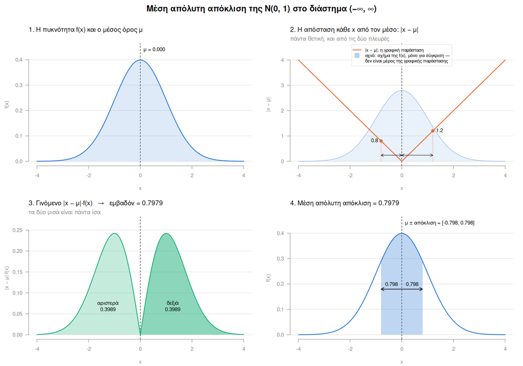

Εικόνα 7: Μέση απόλυτη απόκλιση της $N(0, 1)$ βήμα-βήμα. (`mad_visual.R`)

Η Εικόνα 7 έχει τα ίδια τέσσερα βήματα με την Εικόνα 3. Επειδή όμως η τιμή είναι τώρα στον άξονα $x$, όλα είναι «γυρισμένα»:

**Βήμα 1: πυκνότητα και μέσος όρος** (πάνω αριστερά). Ο μέσος όρος είναι τώρα **κάθετη** γραμμή, γιατί είναι θέση στον άξονα $x$.

**Βήμα 2: η απόσταση $|x - \mu|$** (πάνω δεξιά). Ένα «V» με κορυφή στο $\mu$. Αυτό το πάνελ **δεν εξαρτάται από την κατανομή**, μόνο από το $\mu$. Είναι ο «χάρακας» με τον οποίο μετράμε. Η αχνή μπλε καμπύλη από πίσω **δεν είναι μέρος της γραφικής παράστασης**. Μπαίνει μόνο για σύγκριση, για να φαίνεται ποιες αποστάσεις θα έχουν μεγάλο βάρος στο επόμενο βήμα.

**Βήμα 3: το γινόμενο $|x - \mu| \cdot f(x)$** (κάτω αριστερά). Εδώ το βάρος δεν είναι σταθερό, οπότε πρέπει πράγματι να πολλαπλασιάσουμε. Το σχήμα με τις δύο «καμπούρες» βγαίνει από τη σύγκριση του βήματος 2:

- κοντά στο $\mu$ το βάρος είναι μεγάλο αλλά η απόσταση σχεδόν 0,
- μακριά από το $\mu$ η απόσταση είναι μεγάλη αλλά το βάρος σχεδόν 0,
- στη μέση και τα δύο είναι «αρκετά» μεγάλα, και εκεί είναι οι κορυφές.

Το αριστερό και το δεξί μισό είναι πάλι **ίσα**, για τον ίδιο λόγο με πριν.

**Βήμα 4: το αποτέλεσμα** (κάτω δεξιά). Η απόκλιση είναι απόσταση στον άξονα $x$, και η ζώνη $\mu \pm \text{ΜΑΑ}$ είναι τώρα **κάθετη**.

**Κώδικας**

```r
mad_normal <- integrate(function(x) abs(x - mu) * f(x), -Inf, Inf)$value
c(mad = mad_normal, `√(2/π)` = sqrt(2 / pi))
```

```
      mad    √(2/π)
0.7978846 0.7978846
```

## Μια δεύτερη πυκνότητα: το τρίγωνο

Για να φανεί ότι η μέθοδος δεν αφορά μόνο την κανονική, παίρνουμε μια **τριγωνική** πυκνότητα: ισοσκελές τρίγωνο με κορυφή στο 0, από το $-1$ έως το $+1$.

$$f(x) = 1 - |x|, \qquad -1 \le x \le 1$$

Το εμβαδόν είναι βάση × ύψος / 2 $= 2 \cdot 1 / 2 = 1$, άρα είναι ήδη πυκνότητα.

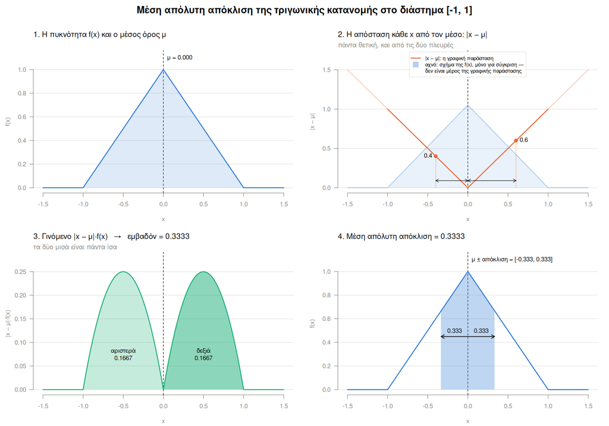

Εικόνα 8: Μέση απόλυτη απόκλιση της τριγωνικής κατανομής. (`mad_visual.R`)

Σύγκρινε το **βήμα 2** με εκείνο της Εικόνα 7. Το πορτοκαλί «V» είναι το ίδιο, γιατί και οι δύο κατανομές έχουν $\mu = 0$. Αλλάζει μόνο το αχνό σχήμα από πίσω, τρίγωνο αντί για καμπάνα. Η διαφορά των κατανομών εμφανίζεται στο **βήμα 3**, όπου το γινόμενο $|x|(1 - |x|)$ δίνει δύο **παραβολές**. Εδώ το ολοκλήρωμα βγαίνει και με το χέρι:

$$\int_{-1}^{1} |x|\,(1 - |x|)\,dx = 2 \int_{0}^{1} (x - x^2)\,dx
= 2 \left( \frac{1}{2} - \frac{1}{3} \right) = \frac{1}{3}$$

**Κώδικας**

```r
triangle <- function(x) pmax(1 - abs(x), 0)
mu_tri   <- integrate(function(x) x * triangle(x), -1, 1)$value
integrate(function(x) abs(x - mu_tri) * triangle(x), -1, 1)$value
```

```
[1] 0.3333333
```

# Επέκταση: διακύμανση

## Ίδιο μοτίβο, με τετράγωνο

Η **διακύμανση** μετράει κι αυτή πόσο απλωμένες είναι οι τιμές. Στη θέση της απόλυτης τιμής χρησιμοποιεί το **τετράγωνο** της απόστασης:

$$\text{απλή συνάρτηση: } \frac{1}{b-a} \int_a^b (h(x) - \bar{y})^2\,dx
\qquad\qquad
\text{πυκνότητα: } \sigma^2 = \int (x - \mu)^2 \cdot f(x)\,dx$$

Το τετράγωνο κάνει κι αυτό όλες τις αποστάσεις θετικές, αλλά **δίνει πολύ μεγαλύτερο βάρος στις μεγάλες**. Μια απόσταση 3 μετράει 9, ενώ μια απόσταση 0.5 μετράει 0.25. Επειδή το αποτέλεσμα είναι σε «τετραγωνισμένες» μονάδες, παίρνουμε συνήθως τη ρίζα του, την **τυπική απόκλιση** $\sigma = \sqrt{\sigma^2}$, για να γυρίσουμε στις μονάδες του $x$.

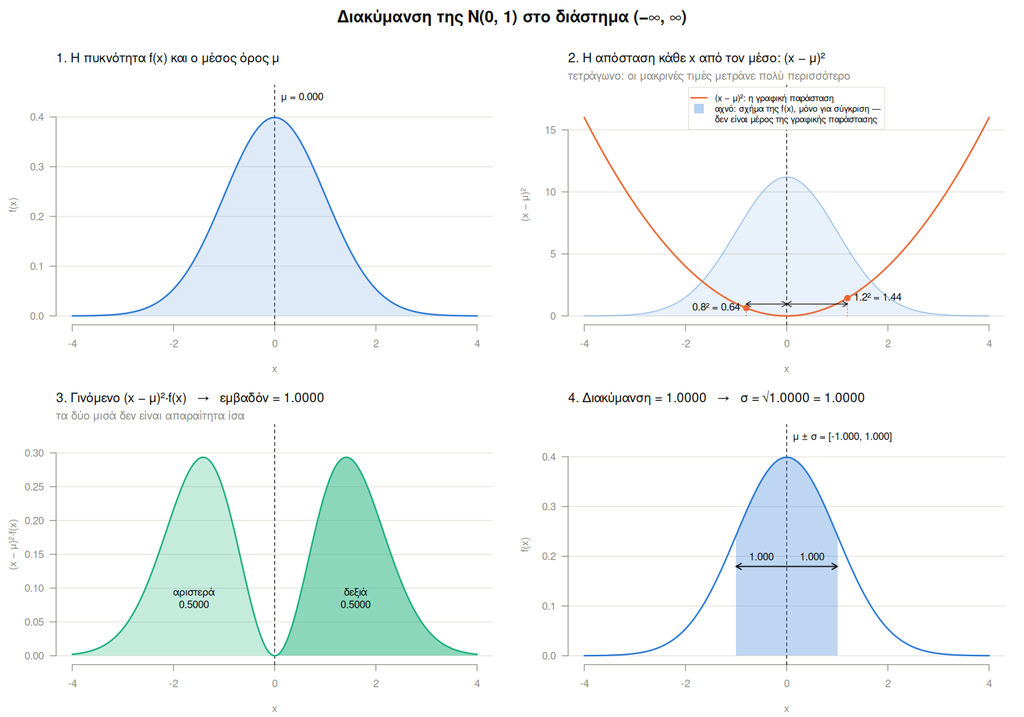

Εικόνα 9: Διακύμανση της $N(0, 1)$ βήμα-βήμα. (`mad_visual.R`)

Η Εικόνα 9 έχει τα ίδια τέσσερα βήματα με την Εικόνα 7:

- Στο **βήμα 2** το «V» γίνεται **παραβολή** $(x - \mu)^2$, που ανεβαίνει πολύ πιο απότομα μακριά από το $\mu$.
- Στο **βήμα 3** οι καμπούρες απομακρύνονται από το κέντρο, στο $\pm\sqrt{2}$ αντί για $\pm 1$. Οι μακρινές τιμές μετράνε περισσότερο.
- Τα δύο μισά εδώ είναι ίσα **μόνο** επειδή η κανονική είναι συμμετρική. Στη διακύμανση αυτό δεν ισχύει γενικά. Το συνοδευτικό κείμενο για το διάστημα δείχνει μια περίπτωση στην οποία διαφέρουν.
- Στο **βήμα 4** η ζώνη είναι $\mu \pm \sigma$.

**Κώδικας**

```r
var_values <- function(h) {
  ybar <- mean_values(h)
  integrate(function(x) (h(x) - ybar)^2, a, b)$value / (b - a)
}
var_density <- function(dens, lo, hi) {
  m <- integrate(function(x) x * dens(x), lo, hi)$value
  integrate(function(x) (x - m)^2 * dens(x), lo, hi)$value
}
c(`2x` = var_values(h_lin), `x²` = var_values(h_cvx), `2x − x²` = var_values(h_ccv),
  `N(0, 1)` = var_density(f, -Inf, Inf), `τρίγωνο` = var_density(triangle, -1, 1))
```

```
        2x         x²    2x − x²    N(0, 1)    τρίγωνο
0.33333333 0.08888889 0.08888889 1.00000000 0.16666667
```

Με το χέρι: για το $2x$ είναι $\int_0^1 (2x - 1)^2\,dx = 1/3$. Για το $x^2$ είναι $\int_0^1 x^4\,dx - (1/3)^2 = 1/5 - 1/9 = 4/45$, και το ίδιο για το $2x - x^2$, για τον ίδιο λόγο με την απόκλιση. Για το τρίγωνο είναι $2\int_0^1 x^2(1 - x)\,dx = 1/6$.

## Γιατί η διακύμανση χρησιμοποιείται πιο συχνά

Η μέση απόλυτη απόκλιση είναι ευκολότερη στην ερμηνεία: είναι απλώς η μέση απόσταση από τον μέσο όρο. Στην πράξη όμως η διακύμανση και η τυπική απόκλιση χρησιμοποιούνται πολύ περισσότερο, για τρεις λόγους:

1. **Το τετράγωνο δεν έχει «γωνία».** Η $|x - \mu|$ σπάει απότομα στο $\mu$, ενώ η $(x - \mu)^2$ είναι ομαλή. Οι πράξεις γίνονται πιο εύκολες. Π.χ. αναπτύσσοντας το τετράγωνο προκύπτει ο σύντομος τύπος $\sigma^2 = \int x^2 f(x)\,dx - \mu^2$, που χρησιμοποιήσαμε παραπάνω για το $x^2$ ($1/5 - 1/9$). Για την απόλυτη τιμή δεν υπάρχει αντίστοιχος τύπος, και πρέπει να σπάσουμε το ολοκλήρωμα στο σημείο όπου αλλάζει πρόσημο.
2. **Οι διακυμάνσεις προστίθενται.** Αν δύο τυχαία μεγέθη είναι ανεξάρτητα, η διακύμανση του αθροίσματός τους είναι το άθροισμα των διακυμάνσεών τους. Για τη μέση απόλυτη απόκλιση δεν ισχύει κάτι τέτοιο.
3. **Το $\sigma$ είναι η παράμετρος της κανονικής.** Η κανονική γράφεται $N(\mu, \sigma^2)$, και περίπου το 68% του βάρους της είναι στο $\mu \pm \sigma$ και το 95% στο $\mu \pm 2\sigma$.

Η μέση απόλυτη απόκλιση έχει ένα πλεονέκτημα: **επηρεάζεται λιγότερο από ακραίες τιμές**, γιατί δεν τις υψώνει στο τετράγωνο. Για την κανονική τα δύο μέτρα είναι ανάλογα: $\text{ΜΑΑ} = \sigma \sqrt{2/\pi} \approx 0.8\,\sigma$.

### Διακύμανση και τυπική απόκλιση: τι είναι τι

Τα δύο μεγέθη συνδέονται στενά, αλλά δεν είναι το ίδιο:

- Η **διακύμανση** είναι το $\sigma^2$: ο μέσος όρος των **τετραγώνων** των αποστάσεων από τον μέσο όρο. Μετριέται σε τετραγωνισμένες μονάδες.
- Η **τυπική απόκλιση** είναι το $\sigma = \sqrt{\sigma^2}$: η τετραγωνική ρίζα της διακύμανσης. Μετριέται στις ίδιες μονάδες με τις τιμές και εκφράζει μια τυπική απόσταση από τον μέσο όρο.

Για παράδειγμα, αν η διακύμανση είναι $\sigma^2 = 4$, η τυπική απόκλιση είναι $\sigma = 2$. Στην $N(0, 1)$ και τα δύο έχουν αριθμητική τιμή 1, αλλά αυτό είναι ειδική περίπτωση: το πρώτο είναι $\sigma^2 = 1$ και το δεύτερο $\sigma = 1$.

# Σύνοψη

Όλα τα μέτρα του κειμένου είναι **ένας** τύπος:

$$\int (\text{ποσότητα}) \cdot (\text{βάρος})\,dx$$

| Μέτρο | Ποσότητα | Απλή συνάρτηση (ομοιόμορφο βάρος $\frac{1}{b-a}$) | Πυκνότητα (βάρος $f(x)$) |
| --- | --- | --- | --- |
| Μέσος όρος | η τιμή | $h(x)$ | $x$ |
| Μέση απόλυτη απόκλιση | η απόσταση από τον μέσο | $\lvert h(x) - \bar{y} \rvert$ | $\lvert x - \mu \rvert$ |
| Διακύμανση | το τετράγωνο της απόστασης | $(h(x) - \bar{y})^2$ | $(x - \mu)^2$ |

**Κώδικας**

```r
describe_values <- function(h) {
  c(mean_values(h), mad_values(h), var_values(h))
}
describe_density <- function(dens, lo, hi) {
  m <- integrate(function(x) x * dens(x), lo, hi)$value
  c(m, integrate(function(x) abs(x - m) * dens(x), lo, hi, rel.tol = 1e-10)$value,
    var_density(dens, lo, hi))
}
tab <- rbind(
  `h(x) = 2x στο [0, 1]`      = describe_values(h_lin),
  `h(x) = x² στο [0, 1]`      = describe_values(h_cvx),
  `h(x) = 2x − x² στο [0, 1]` = describe_values(h_ccv),
  `πυκνότητα N(0, 1)`         = describe_density(f, -Inf, Inf),
  `πυκνότητα τρίγωνο`         = describe_density(triangle, -1, 1)
)
colnames(tab) <- c("Μέσος όρος", "Μέση απόλυτη απόκλιση", "Διακύμανση")
knitr::kable(round(tab, 4))
```

Πίνακας 1: Όλα τα αποτελέσματα του κειμένου, υπολογισμένα με ολοκληρώματα.

|  | Μέσος όρος | Μέση απόλυτη απόκλιση | Διακύμανση |
| --- | --- | --- | --- |
| h(x) = 2x στο [0, 1] | 1.0000 | 0.5000 | 0.3333 |
| h(x) = x² στο [0, 1] | 0.3333 | 0.2566 | 0.0889 |
| h(x) = 2x − x² στο [0, 1] | 0.6667 | 0.2566 | 0.0889 |
| πυκνότητα N(0, 1) | 0.0000 | 0.7979 | 1.0000 |
| πυκνότητα τρίγωνο | 0.0000 | 0.3333 | 0.1667 |

# Ασκήσεις

Δοκίμασε πρώτα με το χέρι, και μετά άνοιξε τη λύση για να ελέγξεις.

**1. Μισές τιμές.** Υπολόγισε τον μέσο όρο και τη μέση απόλυτη απόκλιση των τιμών της $h(x) = x$ στο $[0, 1]$. Σύγκρινε με το $2x$. Μπορείς να προβλέψεις το αποτέλεσμα χωρίς ολοκλήρωμα;

**ΣυμβουλήΛύση**

$\bar{y} = \int_0^1 x\,dx = 1/2$ και $\text{ΜΑΑ} = \int_0^1 |x - 1/2|\,dx = 1/4$. Είναι ακριβώς τα **μισά** από το $2x$ (1 και 0.5). Όταν όλες οι τιμές μειώνονται στο μισό, το ίδιο συμβαίνει στο κέντρο και σε κάθε απόσταση από αυτό. Η διακύμανση όμως γίνεται το **ένα τέταρτο** ($1/12$ αντί για $1/3$), γιατί μετράει τετράγωνα αποστάσεων.

**2. Μετατόπιση.** Τι γίνεται με τον μέσο όρο και την απόκλιση για το $h(x) = 2x + 5$ στο $[0, 1]$;

**ΣυμβουλήΛύση**

Ο μέσος όρος ανεβαίνει κατά 5 ($\bar{y} = 6$), αλλά η απόκλιση μένει **ίδια** (0.5). Όλη η καμπύλη ανεβαίνει μαζί με την κόκκινη γραμμή, οπότε οι αποστάσεις από αυτήν δεν αλλάζουν. Η απόκλιση μετράει **πόσο απλωμένες** είναι οι τιμές, όχι **πού** βρίσκονται.

**3. Πιο κυρτή.** Πρόβλεψε αν ο μέσος όρος των τιμών της $h(x) = x^3$ στο $[0, 1]$ θα είναι μεγαλύτερος ή μικρότερος από του $x^2$ ($1/3$). Μετά υπολόγισε τον μέσο όρο και τη μέση απόλυτη απόκλιση.

**ΣυμβουλήΛύση**

Το $x^3$ μένει χαμηλά ακόμα περισσότερο, οπότε ο μέσος είναι **μικρότερος**: $\bar{y} = \int_0^1 x^3\,dx = 1/4$.

Για την απόκλιση, η καμπύλη περνάει το $\bar{y}$ στο $x_* = (1/4)^{1/3} \approx 0.630$. Το κομμάτι κάτω από το $\bar{y}$ έχει εμβαδόν

$$\int_0^{x_*} \left(\tfrac{1}{4} - x^3\right) dx = \frac{x_*}{4} - \frac{x_*^4}{4}
= \frac{x_*}{4}\left(1 - \frac{1}{4}\right) = \frac{3 x_*}{16}$$

και, επειδή τα δύο κομμάτια είναι ίσα, $\text{ΜΑΑ} = 2 \cdot \frac{3 x_*}{16} = \frac{3 x_*}{8} \approx 0.236$.

**Κώδικας**

```r
c(mean = integrate(function(x) x^3, 0, 1)$value,
  mad  = integrate(function(x) abs(x^3 - 1/4), 0, 1, rel.tol = 1e-10)$value)
```

```
     mean       mad
0.2500000 0.2362352
```

**4. Ίδιος τύπος, άλλος ρόλος.** Η $f(x) = 2x$ στο $[0, 1]$ είναι έγκυρη πυκνότητα; Αν ναι, υπολόγισε τον μέσο όρο της και σύγκρινέ τον με τον μέσο όρο των **τιμών** της $h(x) = 2x$ (που είναι 1). Γιατί διαφέρουν;

**ΣυμβουλήΛύση**

Είναι έγκυρη: $2x \ge 0$ και $\int_0^1 2x\,dx = 1$. Ο μέσος όρος της είναι

$$\mu = \int_0^1 x \cdot 2x\,dx = \frac{2}{3}$$

Διαφέρει από το 1 επειδή το «$2x$» παίζει **άλλον ρόλο**:

- ως **απλή συνάρτηση**, το $2x$ είναι η **τιμή**, από 0 έως 2, με ίσο βάρος. Ο μέσος είναι στη μέση, στο 1.
- ως **πυκνότητα**, το $2x$ είναι το **βάρος**, και οι τιμές είναι τα $x$ από 0 έως
  1. Επειδή το βάρος μεγαλώνει προς τα δεξιά, το σημείο ισορροπίας πάει δεξιά από το κέντρο 0.5, στο $2/3$.

Είναι ακριβώς η αλλαγή ρόλου του άξονα $y$ που είδαμε στη μετάβαση. Η διακύμανση της πυκνότητας είναι $\int_0^1 x^2 \cdot 2x\,dx - (2/3)^2 = 1/2 - 4/9 = 1/18$.

**5. Πόσο βάρος στη ζώνη.** Στην $N(0, 1)$, τι ποσοστό του βάρους βρίσκεται στη ζώνη $\mu \pm \sigma$ και τι ποσοστό στη ζώνη $\mu \pm \text{ΜΑΑ}$; Χρειάζεται ένα ολοκλήρωμα της πυκνότητας σε καθεμία.

**ΣυμβουλήΛύση**

Το βάρος σε μια ζώνη είναι το εμβαδόν κάτω από την $f$ σε αυτή:

**Κώδικας**

```r
c(`μ ± σ`   = integrate(f, -1, 1)$value,
  `μ ± ΜΑΑ` = integrate(f, -sqrt(2 / pi), sqrt(2 / pi))$value)
```

```
    μ ± σ   μ ± ΜΑΑ
0.6826895 0.5750625
```

Περίπου 68% στο $\mu \pm \sigma$ και 58% στο $\mu \pm \text{ΜΑΑ}$. Η δεύτερη ζώνη είναι στενότερη, γιατί $\text{ΜΑΑ} \approx 0.8\,\sigma$.

# Γλωσσάρι

| Ελληνικά | Αγγλικά |
| --- | --- |
| ορισμένο ολοκλήρωμα | definite integral |
| τιμή | value |
| βάρος | weight |
| μέσος όρος | mean |
| σταθμισμένος μέσος όρος | weighted mean |
| μέση απόλυτη απόκλιση (ΜΑΑ) | mean absolute deviation (MAD) |
| διακύμανση | variance |
| τυπική απόκλιση | standard deviation |
| πυκνότητα πιθανότητας | probability density function (PDF) |
| κατανομή πιθανότητας | probability distribution |
| ομοιόμορφη κατανομή | uniform distribution |
| κανονική κατανομή | normal distribution |
| τυπική κανονική κατανομή | standard normal distribution |
| τριγωνική κατανομή | triangular distribution |

## Συντελεστές

Συγγραφή: [Kostas Maistrelis](https://maistrelis.com) (ORCID 0000-0002-0851-2866). Το κείμενο, οι εικόνες και ο κώδικας R αναπτύχθηκαν σε συνεργασία με το [Claude](https://www.anthropic.com/claude) της Anthropic.

Γλωσσική επιμέλεια: [Codex](https://openai.com/codex/) της OpenAI.

## Άδεια χρήσης

Το κείμενο και οι εικόνες διατίθενται με την άδεια [Creative Commons Αναφορά Δημιουργού 4.0 (CC BY 4.0)](https://creativecommons.org/licenses/by/4.0/deed.el): μπορείς να τα χρησιμοποιήσεις, να τα αλλάξεις και να τα μοιραστείς, αρκεί να αναφέρεις την πηγή. Ο κώδικας (τα scripts R, το Makefile και τα κομμάτια κώδικα του κειμένου) διατίθεται με την άδεια [MIT](https://opensource.org/license/mit).

## Υποσημειώσεις

[^1]: Κάθε πιθανότητα είναι από 0 έως 1, και η πιθανότητα του συνόλου όλων των δυνατών αποτελεσμάτων είναι 1. Στη διακριτή περίπτωση αυτό εκφράζεται ως άθροισμα πιθανοτήτων· στη συνεχή περίπτωση το αντίστοιχο είναι ολοκλήρωμα.